# Station #5021

Bryan Blanc

July 07, 2015

This is a summary of the times, lane numbers, and quantities that have missing data for this PORTAL station. This document is dynamic and can be regenerated.

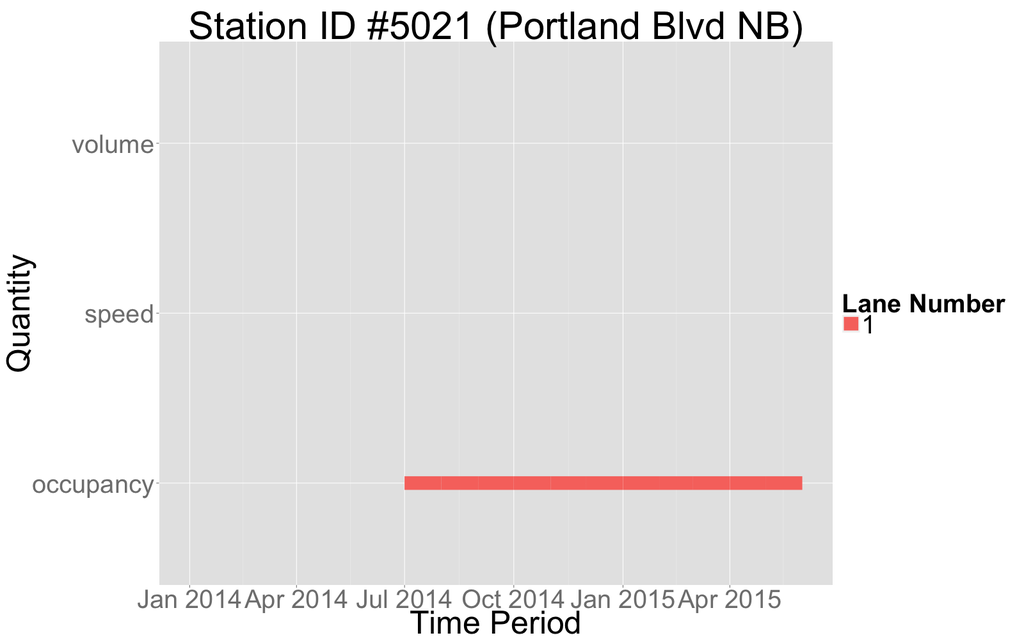

# Data Outages

- Outage Period: 2015-05-01 to 2015-06-01
  - Hours: 0-23
  - Lanes: 1
  - Quantities: NA, occupancy
- Outage Period: 2015-04-01 to 2015-05-01
  - Hours: 0-23
  - Lanes: 1
  - Quantities: NA, occupancy
- Outage Period: 2015-03-01 to 2015-04-01
  - Hours: 0-23
  - Lanes: 1
  - Quantities: NA, occupancy
- Outage Period: 2015-02-01 to 2015-03-01
  - Hours: 0-6,9-23
  - Lanes: 1
  - Quantities: NA, occupancy
- Outage Period: 2015-01-01 to 2015-02-01
  - Hours: 0-8
  - Lanes: 1
  - Quantities: NA, occupancy
- Outage Period: 2014-12-01 to 2015-01-01
  - Hours: 0-23
  - Lanes: 1
  - Quantities: NA, occupancy
- Outage Period: 2014-11-01 to 2014-12-01
  - Hours: 0-23
  - Lanes: 1
  - Quantities: NA, occupancy
- Outage Period: 2014-10-01 to 2014-11-01
  - Hours: 0-23
  - Lanes: 1
  - Quantities: NA, occupancy
- Outage Period: 2014-09-01 to 2014-10-01
  - Hours: 0-8,17-23
  - Lanes: 1
  - Quantities: NA, occupancy
- Outage Period: 2014-08-01 to 2014-09-01
  - Hours: 0-11,17-23
  - Lanes: 1
  - Quantities: NA, occupancy
- Outage Period: 2014-07-01 to 2014-08-01
  - Hours: 0-8
  - Lanes: 1
  - Quantities: NA, occupancy